# Wrangle_act

```python
import pandas as pd
import numpy as np
import sqlite3
import re
import matplotlib.pyplot as plt
import seaborn as sb
from IPython.display import Image
from IPython.core.display import HTML
%matplotlib inline
```

## 1. Gathering data

### twitter_archive_enhanced.csv

```python
#download csv file to my environment and read it as df file
df=pd.read_csv(r'C:\Users\wythe\OneDrive\udacity\twitter api\twitter-archive-enhanced.csv')
```

```python
df.info()
```

```
<class 'pandas.core.frame.DataFrame'>
RangeIndex: 2356 entries, 0 to 2355
Data columns (total 17 columns):
 #   Column                      Non-Null Count  Dtype
---  ------                      --------------  -----
 0   tweet_id                    2356 non-null   int64
 1   in_reply_to_status_id       78 non-null     float64
 2   in_reply_to_user_id         78 non-null     float64
 3   timestamp                   2356 non-null   object
 4   source                      2356 non-null   object
 5   text                        2356 non-null   object
 6   retweeted_status_id         181 non-null    float64
 7   retweeted_status_user_id    181 non-null    float64
 8   retweeted_status_timestamp  181 non-null    object
 9   expanded_urls               2297 non-null   object
 10  rating_numerator            2356 non-null   int64
 11  rating_denominator          2356 non-null   int64
 12  name                        2356 non-null   object
 13  doggo                       2356 non-null   object
 14  floofer                     2356 non-null   object
 15  pupper                      2356 non-null   object
 16  puppo                       2356 non-null   object
dtypes: float64(4), int64(3), object(10)
memory usage: 313.0+ KB
```

```python
df.head()
```

|  | tweet_id | in_reply_to_status_id | in_reply_to_user_id | timestamp | source | text | retweeted_status_id | retweeted_status_user_id | retweeted_status_timestamp | expanded_urls | rating_numerator | rating_denominator | name | doggo | floofer | pupper | puppo |
| --- | --- | --- | --- | --- | --- | --- | --- | --- | --- | --- | --- | --- | --- | --- | --- | --- | --- |
| 0 | 892420643555336193 | NaN | NaN | 2017-08-01 16:23:56 +0000 | <a href="http://twitter.com/download/iphone" r... | This is Phineas. He's a mystical boy. Only eve... | NaN | NaN | NaN | https://twitter.com/dog_rates/status/892420643... | 13 | 10 | Phineas | None | None | None | None |
| 1 | 892177421306343426 | NaN | NaN | 2017-08-01 00:17:27 +0000 | <a href="http://twitter.com/download/iphone" r... | This is Tilly. She's just checking pup on you.... | NaN | NaN | NaN | https://twitter.com/dog_rates/status/892177421... | 13 | 10 | Tilly | None | None | None | None |
| 2 | 891815181378084864 | NaN | NaN | 2017-07-31 00:18:03 +0000 | <a href="http://twitter.com/download/iphone" r... | This is Archie. He is a rare Norwegian Pouncin... | NaN | NaN | NaN | https://twitter.com/dog_rates/status/891815181... | 12 | 10 | Archie | None | None | None | None |
| 3 | 891689557279858688 | NaN | NaN | 2017-07-30 15:58:51 +0000 | <a href="http://twitter.com/download/iphone" r... | This is Darla. She commenced a snooze mid meal... | NaN | NaN | NaN | https://twitter.com/dog_rates/status/891689557... | 13 | 10 | Darla | None | None | None | None |
| 4 | 891327558926688256 | NaN | NaN | 2017-07-29 16:00:24 +0000 | <a href="http://twitter.com/download/iphone" r... | This is Franklin. He would like you to stop ca... | NaN | NaN | NaN | https://twitter.com/dog_rates/status/891327558... | 12 | 10 | Franklin | None | None | None | None |

### image_redictions.tsv

```python
import requests
import os
```

```python
# download this file programmatically using the module Requests
folder_name='image_predictions'
if not os.path.exists(folder_name):
    os.makedirs(folder_name)

url='https://d17h27t6h515a5.cloudfront.net/topher/2017/August/599fd2ad_image-predictions/image-predictions.tsv'
response=requests.get(url)
```

```python
response
```

```
<Response [200]>
```

```python
with open(os.path.join(folder_name,
                      url.split('/')[-1]),mode='wb') as file:
    file.write(response.content)
```

```python
os.listdir(folder_name)
```

```
['image-predictions.tsv']
```

```python
# read the downloaded tsv file as df1 file
df1=pd.read_csv(r'C:\Users\wythe\OneDrive\udacity\twitter api\image_predictions\image-predictions.tsv', sep='\t')
```

```python
df1
```

|  | tweet_id | jpg_url | img_num | p1 | p1_conf | p1_dog | p2 | p2_conf | p2_dog | p3 | p3_conf | p3_dog |
| --- | --- | --- | --- | --- | --- | --- | --- | --- | --- | --- | --- | --- |
| 0 | 666020888022790149 | https://pbs.twimg.com/media/CT4udn0WwAA0aMy.jpg | 1 | Welsh_springer_spaniel | 0.465074 | True | collie | 0.156665 | True | Shetland_sheepdog | 0.061428 | True |
| 1 | 666029285002620928 | https://pbs.twimg.com/media/CT42GRgUYAA5iDo.jpg | 1 | redbone | 0.506826 | True | miniature_pinscher | 0.074192 | True | Rhodesian_ridgeback | 0.072010 | True |
| 2 | 666033412701032449 | https://pbs.twimg.com/media/CT4521TWwAEvMyu.jpg | 1 | German_shepherd | 0.596461 | True | malinois | 0.138584 | True | bloodhound | 0.116197 | True |
| 3 | 666044226329800704 | https://pbs.twimg.com/media/CT5Dr8HUEAA-lEu.jpg | 1 | Rhodesian_ridgeback | 0.408143 | True | redbone | 0.360687 | True | miniature_pinscher | 0.222752 | True |
| 4 | 666049248165822465 | https://pbs.twimg.com/media/CT5IQmsXIAAKY4A.jpg | 1 | miniature_pinscher | 0.560311 | True | Rottweiler | 0.243682 | True | Doberman | 0.154629 | True |
| ... | ... | ... | ... | ... | ... | ... | ... | ... | ... | ... | ... | ... |
| 2070 | 891327558926688256 | https://pbs.twimg.com/media/DF6hr6BUMAAzZgT.jpg | 2 | basset | 0.555712 | True | English_springer | 0.225770 | True | German_short-haired_pointer | 0.175219 | True |
| 2071 | 891689557279858688 | https://pbs.twimg.com/media/DF_q7IAWsAEuuN8.jpg | 1 | paper_towel | 0.170278 | False | Labrador_retriever | 0.168086 | True | spatula | 0.040836 | False |
| 2072 | 891815181378084864 | https://pbs.twimg.com/media/DGBdLU1WsAANxJ9.jpg | 1 | Chihuahua | 0.716012 | True | malamute | 0.078253 | True | kelpie | 0.031379 | True |
| 2073 | 892177421306343426 | https://pbs.twimg.com/media/DGGmoV4XsAAUL6n.jpg | 1 | Chihuahua | 0.323581 | True | Pekinese | 0.090647 | True | papillon | 0.068957 | True |
| 2074 | 892420643555336193 | https://pbs.twimg.com/media/DGKD1-bXoAAIAUK.jpg | 1 | orange | 0.097049 | False | bagel | 0.085851 | False | banana | 0.076110 | False |

2075 rows × 12 columns

### Tweet_json by Tweepy

> Get the values of tweet's 'retweet' counts and 'favorites' counts in the WeRateDogs Twitter by Python's module Tweepy from Twitter API as JSON data.

```python
import tweepy
from tweepy import OAuthHandler
import json
from timeit import default_timer as timer
```

```python
# my API keys and tokens
consumer_key=''
consumer_secret=''
access_token=''
access_secret=''
```

```python
auth=tweepy.OAuthHandler(consumer_key, consumer_secret)
auth.set_access_token(access_token, access_secret)
api=tweepy.API(auth, wait_on_rate_limit=True, wait_on_rate_limit_notify=True)
```

```python
tweet_ids=df.tweet_id.values
len(tweet_ids)
```

```
2356
```

```python
# iteration process on tweet_id
# append aquired data in 'tweet_data'
count=0
tweet_data=[]
fails_dict={}
start=timer()

for tweet_id in tweet_ids:
    count+=1
    print(str(count)+':'+str(tweet_id))

    try:
        tweet=api.get_status(tweet_id, tweet_mode='extended')._json
        print('Success')
        favorites=tweet['favorite_count']
        retweet=tweet['retweet_count']
        tweet_data.append({'tweet_id':int(tweet_id),
                           'favorites':int(favorites),
                           'retweet':int(retweet)})



    except tweepy.TweepError as e:
        print('Fail')
        fails_dict[tweet_id]=e

        pass

end=timer()
print(end-start)
print(fails_dict)
```

[output not shown]

[output cut: 1746 more lines]

[output not shown]

```
Rate limit reached. Sleeping for: 669
```

[output not shown]

[output cut: 1745 more lines]

[output not shown]

```
Rate limit reached. Sleeping for: 666
```

[output not shown]

[output cut: 1058 more lines]

[output not shown]

```python
# read JSON data(tweet_data) as df2 file
df2=pd.DataFrame(tweet_data, columns=(['tweet_id', 'favorites', 'retweet']))
df2
```

|  | tweet_id | favorites | retweet |
| --- | --- | --- | --- |
| 0 | 892420643555336193 | 35565 | 7534 |
| 1 | 892177421306343426 | 30753 | 5589 |
| 2 | 891815181378084864 | 23129 | 3703 |
| 3 | 891689557279858688 | 38845 | 7709 |
| 4 | 891327558926688256 | 37102 | 8316 |
| 5 | 891087950875897856 | 18708 | 2787 |
| 6 | 890971913173991426 | 10869 | 1810 |
| 7 | 890729181411237888 | 59926 | 16856 |
| 8 | 890609185150312448 | 25744 | 3843 |
| 9 | 890240255349198849 | 29373 | 6554 |
| 10 | 890006608113172480 | 28331 | 6550 |
| 11 | 889880896479866881 | 25750 | 4460 |
| 12 | 889665388333682689 | 44288 | 8939 |
| 13 | 889638837579907072 | 24916 | 4000 |
| 14 | 889531135344209921 | 13995 | 2018 |
| 15 | 889278841981685760 | 23246 | 4767 |
| 16 | 888917238123831296 | 26839 | 4010 |
| 17 | 888804989199671297 | 23560 | 3781 |
| 18 | 888554962724278272 | 18195 | 3094 |
| 19 | 888078434458587136 | 20088 | 3102 |
| 20 | 887705289381826560 | 27937 | 4824 |
| 21 | 887517139158093824 | 42767 | 10544 |
| 22 | 887473957103951883 | 63353 | 16095 |
| 23 | 887343217045368832 | 31055 | 9388 |
| 24 | 887101392804085760 | 28272 | 5337 |
| 25 | 886983233522544640 | 32170 | 6849 |
| 26 | 886736880519319552 | 11042 | 2861 |
| 27 | 886680336477933568 | 20761 | 4005 |
| 28 | 886366144734445568 | 19504 | 2831 |
| 29 | 886267009285017600 | 110 | 4 |

[output cut: 2301 more lines]

```python
#save df2 as csv file as 'df2.csv'
df2.to_csv('df2.csv', index=False)
```

## 2. Acessing data

> Assessment of all gathered datasets(df_main, df_class, df_tweet) for qualaity and tidiness issue are performed here. Right after gathering data and before documenting issues found.

> df_main(twitter_archive_enhanced.csv)
> - datatype of ‘timestamp’ is object
> - 'source’ column, tabs are not necessary.
> - 'name’ column, ‘None’ or ‘a’ are in it.
> - 'rating_numerator’ column, the distribution of the values looks abnormal(max=1776 , mean=13.1, min=0)
> - There are unnecessary columns(majority of data in those columns is Nan, ‘in_reply_to_status_id’, ‘in_reply_to_user_id, ‘retweeted_status_id’, ‘retweeted_status_user_id’, ‘retweeted_status_timestamp’)

> df_class(image predictions.tsv)
> - There are rows except dogs
> - The column ‘img_num’ is not necessary
> - 'p1’, ‘p2’, ‘p3’, lowercase and uppercase are mixed
> - Those columns such as ’p1’ and ‘p1_conf’ are not easy to understand( should be renamed as ‘breed’ and ‘p1_conf’ as ‘confidence_level’ )
> - p3’ is not necessary because ‘p1’ + ‘p2’ covers majority

> df_tweet(tweet_json.text)
> - columns name ‘favorites’ and ‘retweet’ should be renamed as ‘favorites_counts’ and ‘retweet_counts’

### Tidiness(2 issues found)

> df_main(twitter_archive_enhanced.csv)
> - dog stages such columns as ‘doggo’, ‘floofer’, ‘pupper’ and ‘puppo’ are untidy. tidying

> 3 dfs(df_main, df_class, df_tweet) merge
> - After cleaning on each df, those dfs are merged.

## 3. Cleaning data

### twitter_archive_enhanced.csv

> This file is read as 'df_main' on which following cleaning process were made.

```python
#create df_main as copy of df
df_main=df.copy()
```

```python
df_main.info()
```

```
<class 'pandas.core.frame.DataFrame'>
RangeIndex: 2356 entries, 0 to 2355
Data columns (total 17 columns):
 #   Column                      Non-Null Count  Dtype
---  ------                      --------------  -----
 0   tweet_id                    2356 non-null   int64
 1   in_reply_to_status_id       78 non-null     float64
 2   in_reply_to_user_id         78 non-null     float64
 3   timestamp                   2356 non-null   object
 4   source                      2356 non-null   object
 5   text                        2356 non-null   object
 6   retweeted_status_id         181 non-null    float64
 7   retweeted_status_user_id    181 non-null    float64
 8   retweeted_status_timestamp  181 non-null    object
 9   expanded_urls               2297 non-null   object
 10  rating_numerator            2356 non-null   int64
 11  rating_denominator          2356 non-null   int64
 12  name                        2356 non-null   object
 13  doggo                       2356 non-null   object
 14  floofer                     2356 non-null   object
 15  pupper                      2356 non-null   object
 16  puppo                       2356 non-null   object
dtypes: float64(4), int64(3), object(10)
memory usage: 313.0+ KB
```

```python
df_main.head()
```

|  | tweet_id | in_reply_to_status_id | in_reply_to_user_id | timestamp | source | text | retweeted_status_id | retweeted_status_user_id | retweeted_status_timestamp | expanded_urls | rating_numerator | rating_denominator | name | doggo | floofer | pupper | puppo |
| --- | --- | --- | --- | --- | --- | --- | --- | --- | --- | --- | --- | --- | --- | --- | --- | --- | --- |
| 0 | 892420643555336193 | NaN | NaN | 2017-08-01 16:23:56 +0000 | <a href="http://twitter.com/download/iphone" r... | This is Phineas. He's a mystical boy. Only eve... | NaN | NaN | NaN | https://twitter.com/dog_rates/status/892420643... | 13 | 10 | Phineas | None | None | None | None |
| 1 | 892177421306343426 | NaN | NaN | 2017-08-01 00:17:27 +0000 | <a href="http://twitter.com/download/iphone" r... | This is Tilly. She's just checking pup on you.... | NaN | NaN | NaN | https://twitter.com/dog_rates/status/892177421... | 13 | 10 | Tilly | None | None | None | None |
| 2 | 891815181378084864 | NaN | NaN | 2017-07-31 00:18:03 +0000 | <a href="http://twitter.com/download/iphone" r... | This is Archie. He is a rare Norwegian Pouncin... | NaN | NaN | NaN | https://twitter.com/dog_rates/status/891815181... | 12 | 10 | Archie | None | None | None | None |
| 3 | 891689557279858688 | NaN | NaN | 2017-07-30 15:58:51 +0000 | <a href="http://twitter.com/download/iphone" r... | This is Darla. She commenced a snooze mid meal... | NaN | NaN | NaN | https://twitter.com/dog_rates/status/891689557... | 13 | 10 | Darla | None | None | None | None |
| 4 | 891327558926688256 | NaN | NaN | 2017-07-29 16:00:24 +0000 | <a href="http://twitter.com/download/iphone" r... | This is Franklin. He would like you to stop ca... | NaN | NaN | NaN | https://twitter.com/dog_rates/status/891327558... | 12 | 10 | Franklin | None | None | None | None |

#### Columns 'doggo', 'floofer', 'pupper' and 'puppo'

> Tidying those four columns in to one colum

```python
# check the numbers of None and doggo
df_main.doggo.value_counts()
```

```
None     2259
doggo      97
Name: doggo, dtype: int64
```

```python
# check the numbers of None and floofer
df_main.floofer.value_counts()
```

```
None       2346
floofer      10
Name: floofer, dtype: int64
```

```python
# check the numbers of None and pupper
df_main.pupper.value_counts()
```

```
None      2099
pupper     257
Name: pupper, dtype: int64
```

```python
# check the numbers of None and puppo
df_main.puppo.value_counts()
```

```
None     2326
puppo      30
Name: puppo, dtype: int64
```

```python
# create new df as 'dog_stage' to combine those four columns + 'tweet_id'
dog_stage=df_main.filter(['tweet_id','doggo',
                           'floofer','pupper','puppo'], axis=1).copy()
dog_stage.head()
```

|  | tweet_id | doggo | floofer | pupper | puppo |
| --- | --- | --- | --- | --- | --- |
| 0 | 892420643555336193 | None | None | None | None |
| 1 | 892177421306343426 | None | None | None | None |
| 2 | 891815181378084864 | None | None | None | None |
| 3 | 891689557279858688 | None | None | None | None |
| 4 | 891327558926688256 | None | None | None | None |

```python
#'dog_stage' melt
dog_stage=pd.melt(dog_stage,
                   id_vars=['tweet_id'],
                   value_vars=['doggo','floofer','pupper','puppo'],
                  value_name='dog_stage')
dog_stage.head()
```

|  | tweet_id | variable | dog_stage |
| --- | --- | --- | --- |
| 0 | 892420643555336193 | doggo | None |
| 1 | 892177421306343426 | doggo | None |
| 2 | 891815181378084864 | doggo | None |
| 3 | 891689557279858688 | doggo | None |
| 4 | 891327558926688256 | doggo | None |

```python
#check new column 'variable' as a result of melt
dog_stage.variable.value_counts()
```

```
puppo      2356
floofer    2356
pupper     2356
doggo      2356
Name: variable, dtype: int64
```

```python
#drop 'variable'
dog_stage.drop('variable',axis=1, inplace=True)
dog_stage.head()
```

|  | tweet_id | dog_stage |
| --- | --- | --- |
| 0 | 892420643555336193 | None |
| 1 | 892177421306343426 | None |
| 2 | 891815181378084864 | None |
| 3 | 891689557279858688 | None |
| 4 | 891327558926688256 | None |

```python
#check dog_stage columns
dog_stage.dog_stage.value_counts()
```

```
None       9030
pupper      257
doggo        97
puppo        30
floofer      10
Name: dog_stage, dtype: int64
```

```python
#create new df 'dogitionary' that excludes rows with None from 'dog_stage'
dogitionary=dog_stage.query('dog_stage!="None"')
```

```python
#check 'dogitionary'
dogitionary.dog_stage.value_counts()
```

```
pupper     257
doggo       97
puppo       30
floofer     10
Name: dog_stage, dtype: int64
```

```python
#check duplication of 'dogitionary'
dogitionary.duplicated().sum()
```

```
0
```

```python
# merge 'df_main' with 'dogitonary'
df_main=pd.merge(df_main, dogitionary, on=['tweet_id'], how='left')
df_main.head()
```

|  | tweet_id | in_reply_to_status_id | in_reply_to_user_id | timestamp | source | text | retweeted_status_id | retweeted_status_user_id | retweeted_status_timestamp | expanded_urls | rating_numerator | rating_denominator | name | doggo | floofer | pupper | puppo | dog_stage |
| --- | --- | --- | --- | --- | --- | --- | --- | --- | --- | --- | --- | --- | --- | --- | --- | --- | --- | --- |
| 0 | 892420643555336193 | NaN | NaN | 2017-08-01 16:23:56 +0000 | <a href="http://twitter.com/download/iphone" r... | This is Phineas. He's a mystical boy. Only eve... | NaN | NaN | NaN | https://twitter.com/dog_rates/status/892420643... | 13 | 10 | Phineas | None | None | None | None | NaN |
| 1 | 892177421306343426 | NaN | NaN | 2017-08-01 00:17:27 +0000 | <a href="http://twitter.com/download/iphone" r... | This is Tilly. She's just checking pup on you.... | NaN | NaN | NaN | https://twitter.com/dog_rates/status/892177421... | 13 | 10 | Tilly | None | None | None | None | NaN |
| 2 | 891815181378084864 | NaN | NaN | 2017-07-31 00:18:03 +0000 | <a href="http://twitter.com/download/iphone" r... | This is Archie. He is a rare Norwegian Pouncin... | NaN | NaN | NaN | https://twitter.com/dog_rates/status/891815181... | 12 | 10 | Archie | None | None | None | None | NaN |
| 3 | 891689557279858688 | NaN | NaN | 2017-07-30 15:58:51 +0000 | <a href="http://twitter.com/download/iphone" r... | This is Darla. She commenced a snooze mid meal... | NaN | NaN | NaN | https://twitter.com/dog_rates/status/891689557... | 13 | 10 | Darla | None | None | None | None | NaN |
| 4 | 891327558926688256 | NaN | NaN | 2017-07-29 16:00:24 +0000 | <a href="http://twitter.com/download/iphone" r... | This is Franklin. He would like you to stop ca... | NaN | NaN | NaN | https://twitter.com/dog_rates/status/891327558... | 12 | 10 | Franklin | None | None | None | None | NaN |

```python
df_main.info()
```

```
<class 'pandas.core.frame.DataFrame'>
Int64Index: 2370 entries, 0 to 2369
Data columns (total 18 columns):
 #   Column                      Non-Null Count  Dtype
---  ------                      --------------  -----
 0   tweet_id                    2370 non-null   int64
 1   in_reply_to_status_id       79 non-null     float64
 2   in_reply_to_user_id         79 non-null     float64
 3   timestamp                   2370 non-null   object
 4   source                      2370 non-null   object
 5   text                        2370 non-null   object
 6   retweeted_status_id         183 non-null    float64
 7   retweeted_status_user_id    183 non-null    float64
 8   retweeted_status_timestamp  183 non-null    object
 9   expanded_urls               2311 non-null   object
 10  rating_numerator            2370 non-null   int64
 11  rating_denominator          2370 non-null   int64
 12  name                        2370 non-null   object
 13  doggo                       2370 non-null   object
 14  floofer                     2370 non-null   object
 15  pupper                      2370 non-null   object
 16  puppo                       2370 non-null   object
 17  dog_stage                   394 non-null    object
dtypes: float64(4), int64(3), object(11)
memory usage: 351.8+ KB
```

```python
#pick up necessary columns from 'df_main'
df_main=df_main[['tweet_id','timestamp','source','text','rating_numerator','rating_denominator',
                 'name','dog_stage']]
```

```python
#check dog_stage is propery included in 'df_main'
df_main.dog_stage.value_counts()
```

```
pupper     257
doggo       97
puppo       30
floofer     10
Name: dog_stage, dtype: int64
```

> created 'dog_stage' column insted of untidy four columns in 'df_main'

```python
#create new df as 'de_main_clean' for cleaning operations
df_main_clean=df_main.copy()
df_main_clean.head()
```

|  | tweet_id | timestamp | source | text | rating_numerator | rating_denominator | name | dog_stage |
| --- | --- | --- | --- | --- | --- | --- | --- | --- |
| 0 | 892420643555336193 | 2017-08-01 16:23:56 +0000 | <a href="http://twitter.com/download/iphone" r... | This is Phineas. He's a mystical boy. Only eve... | 13 | 10 | Phineas | NaN |
| 1 | 892177421306343426 | 2017-08-01 00:17:27 +0000 | <a href="http://twitter.com/download/iphone" r... | This is Tilly. She's just checking pup on you.... | 13 | 10 | Tilly | NaN |
| 2 | 891815181378084864 | 2017-07-31 00:18:03 +0000 | <a href="http://twitter.com/download/iphone" r... | This is Archie. He is a rare Norwegian Pouncin... | 12 | 10 | Archie | NaN |
| 3 | 891689557279858688 | 2017-07-30 15:58:51 +0000 | <a href="http://twitter.com/download/iphone" r... | This is Darla. She commenced a snooze mid meal... | 13 | 10 | Darla | NaN |
| 4 | 891327558926688256 | 2017-07-29 16:00:24 +0000 | <a href="http://twitter.com/download/iphone" r... | This is Franklin. He would like you to stop ca... | 12 | 10 | Franklin | NaN |

```python
df_main_clean.info()
```

```
<class 'pandas.core.frame.DataFrame'>
Int64Index: 2370 entries, 0 to 2369
Data columns (total 8 columns):
 #   Column              Non-Null Count  Dtype
---  ------              --------------  -----
 0   tweet_id            2370 non-null   int64
 1   timestamp           2370 non-null   object
 2   source              2370 non-null   object
 3   text                2370 non-null   object
 4   rating_numerator    2370 non-null   int64
 5   rating_denominator  2370 non-null   int64
 6   name                2370 non-null   object
 7   dog_stage           394 non-null    object
dtypes: int64(3), object(5)
memory usage: 166.6+ KB
```

```python
#dtype of 'timestamp' change from 'object' to 'datetime'
df_main_clean.timestamp=pd.to_datetime(df_main_clean.timestamp)
```

```python
df_main_clean.info()
```

```
<class 'pandas.core.frame.DataFrame'>
Int64Index: 2370 entries, 0 to 2369
Data columns (total 8 columns):
 #   Column              Non-Null Count  Dtype
---  ------              --------------  -----
 0   tweet_id            2370 non-null   int64
 1   timestamp           2370 non-null   datetime64[ns, UTC]
 2   source              2370 non-null   object
 3   text                2370 non-null   object
 4   rating_numerator    2370 non-null   int64
 5   rating_denominator  2370 non-null   int64
 6   name                2370 non-null   object
 7   dog_stage           394 non-null    object
dtypes: datetime64[ns, UTC](1), int64(3), object(4)
memory usage: 166.6+ KB
```

```python
# set all rows in output
pd.set_option('max_rows',None)
#check name of 'name' column
df_main_clean.name.value_counts()
```

```
None              753
a                  55
Charlie            12
Cooper             11
Lucy               11
Oliver             11
Penny              10
Lola               10
Tucker             10
Bo                  9
Winston             9
the                 8
Sadie               8
an                  7
Bailey              7
Daisy               7
Buddy               7
Toby                7
Stanley             6
Jax                 6
Koda                6
Scout               6
Jack                6
Rusty               6
Leo                 6
Oscar               6
Dave                6
Milo                6
Bella               6
just                6
Phil                5
Alfie               5
Chester             5
Maggie              5
Finn                5
Bentley             5
Oakley              5
Sammy               5
Sunny               5
very                5
```

[output cut: 903 more lines]

```
Katie               1
Randall             1
Maxwell             1
Winifred            1
Bauer               1
Zeus                1
Zoe                 1
Joshwa              1
Willow              1
Goliath             1
Swagger             1
Cilantro            1
Kawhi               1
Dietrich            1
Name: name, dtype: int64
```

```python
# incorrect names
df_main_clean[df_main_clean.name.str.islower()].name.value_counts()
```

```
a               55
the              8
an               7
just             6
very             5
one              4
quite            4
getting          2
mad              2
actually         2
not              2
incredibly       1
his              1
infuriating      1
officially       1
space            1
such             1
old              1
all              1
by               1
light            1
my               1
unacceptable     1
life             1
this             1
Name: name, dtype: int64
```

```python
#replace incorrect names such as 'None', 'a' to NaN in the 'name' column

df_main_clean.loc[df_main_clean.name.str.islower()==True, 'name']= np.nan
```

```python
df_main_clean.name.value_counts()
```

```
None              753
Charlie            12
Lucy               11
Cooper             11
Oliver             11
Lola               10
Penny              10
Tucker             10
Bo                  9
Winston             9
Sadie               8
Toby                7
Daisy               7
Buddy               7
Bailey              7
Jax                 6
Oscar               6
Stanley             6
Rusty               6
Koda                6
Bella               6
Dave                6
Leo                 6
Scout               6
Milo                6
Jack                6
Sunny               5
Phil                5
Maggie              5
Sammy               5
Alfie               5
Gus                 5
Chester             5
George              5
Bentley             5
Finn                5
Louis               5
Larry               5
Oakley              5
Shadow              4
```

[output cut: 878 more lines]

```
Rufio               1
Cora                1
Rooney              1
Antony              1
Katie               1
Randall             1
Orion               1
Maxwell             1
Bauer               1
Zeus                1
Zoe                 1
Joshwa              1
Willow              1
Dietrich            1
Name: name, dtype: int64
```

```python
# remove retweet
df_main_clean.text.str.startswith("RT")
```

```
0       False
1       False
2       False
3       False
4       False
5       False
6       False
7       False
8       False
9       False
10      False
11      False
12      False
13      False
14      False
```

[output cut: 2356 more lines]

```python
# remove retweets
df_main_clean=df_main_clean[df_main_clean.text.str.startswith("RT")!=True]
```

```python
# rename the long column names
df_main_clean.rename(columns={'rating_numerator':'rating',
                             'rating_denominator':'rating_d'}, inplace=True)
```

```python
#check the remes done properly
df_main_clean.head()
```

|  | tweet_id | timestamp | source | text | rating | rating_d | name | dog_stage |
| --- | --- | --- | --- | --- | --- | --- | --- | --- |
| 0 | 892420643555336193 | 2017-08-01 16:23:56+00:00 | <a href="http://twitter.com/download/iphone" r... | This is Phineas. He's a mystical boy. Only eve... | 13 | 10 | Phineas | NaN |
| 1 | 892177421306343426 | 2017-08-01 00:17:27+00:00 | <a href="http://twitter.com/download/iphone" r... | This is Tilly. She's just checking pup on you.... | 13 | 10 | Tilly | NaN |
| 2 | 891815181378084864 | 2017-07-31 00:18:03+00:00 | <a href="http://twitter.com/download/iphone" r... | This is Archie. He is a rare Norwegian Pouncin... | 12 | 10 | Archie | NaN |
| 3 | 891689557279858688 | 2017-07-30 15:58:51+00:00 | <a href="http://twitter.com/download/iphone" r... | This is Darla. She commenced a snooze mid meal... | 13 | 10 | Darla | NaN |
| 4 | 891327558926688256 | 2017-07-29 16:00:24+00:00 | <a href="http://twitter.com/download/iphone" r... | This is Franklin. He would like you to stop ca... | 12 | 10 | Franklin | NaN |

```python
#check the full text of 'source' to remove tab
df_main_clean.source[0]
```

```
'<a href="http://twitter.com/download/iphone" rel="nofollow">Twitter for iPhone</a>'
```

```python
#tab removed by regex
df_main_clean.source=df_main_clean.source.str.replace(r'<(?:a\b[^>]*>|/a>)','')
df_main_clean.head()
```

|  | tweet_id | timestamp | source | text | rating | rating_d | name | dog_stage |
| --- | --- | --- | --- | --- | --- | --- | --- | --- |
| 0 | 892420643555336193 | 2017-08-01 16:23:56+00:00 | Twitter for iPhone | This is Phineas. He's a mystical boy. Only eve... | 13 | 10 | Phineas | NaN |
| 1 | 892177421306343426 | 2017-08-01 00:17:27+00:00 | Twitter for iPhone | This is Tilly. She's just checking pup on you.... | 13 | 10 | Tilly | NaN |
| 2 | 891815181378084864 | 2017-07-31 00:18:03+00:00 | Twitter for iPhone | This is Archie. He is a rare Norwegian Pouncin... | 12 | 10 | Archie | NaN |
| 3 | 891689557279858688 | 2017-07-30 15:58:51+00:00 | Twitter for iPhone | This is Darla. She commenced a snooze mid meal... | 13 | 10 | Darla | NaN |
| 4 | 891327558926688256 | 2017-07-29 16:00:24+00:00 | Twitter for iPhone | This is Franklin. He would like you to stop ca... | 12 | 10 | Franklin | NaN |

```python
#check distribution of values of 'rating'
df_main_clean.rating.describe()
```

```
count    2185.000000
mean       13.206407
std        47.616716
min         0.000000
25%        10.000000
50%        11.000000
75%        12.000000
max      1776.000000
Name: rating, dtype: float64
```

```python
# ceck the abnomal rating ('1776') in the text
df_main_clean.text[991]
```

```
"This is Atticus. He's quite simply America af. 1776/10 https://t.co/GRXwMxLBkh"
```

> The distribution of values of 'rating' in 'df_main_clean' looks abnomal(i.e. max 1776).

> Check and compare the values between ones in the 'text' and in the 'rating' in 'df_main_clean'.

> First, pick up values from each text by regex and save them to the new df of'rating_text', then compare by the results of describe method and box plot.

```python
#pick up rating values from each text of 'text'columns
rating_text=df_main_clean.text.str.extract('((?:\d+\.)?\d+)\/(\d+)', expand=True)
```

```python
#new df 'rating_text' created
rating_text.columns=['rating_numerator', 'rating_denominator']
rating_text
```

|  | rating_numerator | rating_denominator |
| --- | --- | --- |
| 0 | 13 | 10 |
| 1 | 13 | 10 |
| 2 | 12 | 10 |
| 3 | 13 | 10 |
| 4 | 12 | 10 |
| 5 | 13 | 10 |
| 6 | 13 | 10 |
| 7 | 13 | 10 |
| 8 | 13 | 10 |
| 9 | 14 | 10 |
| 10 | 13 | 10 |
| 11 | 13 | 10 |
| 12 | 13 | 10 |
| 13 | 12 | 10 |
| 14 | 13 | 10 |
| 15 | 13 | 10 |
| 16 | 12 | 10 |
| 17 | 13 | 10 |
| 18 | 13 | 10 |
| 20 | 12 | 10 |
| 21 | 13 | 10 |
| 22 | 14 | 10 |
| 23 | 13 | 10 |
| 24 | 13 | 10 |
| 25 | 12 | 10 |
| 26 | 13 | 10 |
| 27 | 13 | 10 |
| 28 | 13 | 10 |
| 29 | 12 | 10 |
| 30 | 12 | 10 |

[output cut: 2155 more lines]

```python
#dtypes change to float
rating_text=rating_text.astype('float64')
```

```python
rating_text.info()
```

```
<class 'pandas.core.frame.DataFrame'>
Int64Index: 2185 entries, 0 to 2369
Data columns (total 2 columns):
 #   Column              Non-Null Count  Dtype
---  ------              --------------  -----
 0   rating_numerator    2185 non-null   float64
 1   rating_denominator  2185 non-null   float64
dtypes: float64(2)
memory usage: 131.2 KB
```

```python
#check and compare the destribution of values with
#ones of 'rating' column in 'df_main_clean'
rating_text.rating_numerator.describe()
```

```
count    2185.000000
mean       13.168549
std        47.596148
min         0.000000
25%        10.000000
50%        11.000000
75%        12.000000
max      1776.000000
Name: rating_numerator, dtype: float64
```

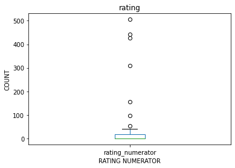

```python
#box plot of values of 'rating_numerator' colum in the df 'rating_text'
rating_text.rating_numerator.value_counts().plot(kind='box', title='rating');
plt.ylabel('COUNT');
plt.xlabel('RATING NUMERATOR');
```

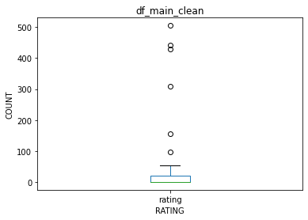

```python
#box plot of values of 'rating' colum in the 'df_main_clean'
df_main_clean.rating.value_counts().plot(kind='box', title='df_main_clean');
plt.ylabel('COUNT');
plt.xlabel('RATING');
```

```python
df_main_clean.head()
```

|  | tweet_id | timestamp | source | text | rating | rating_d | name | dog_stage |
| --- | --- | --- | --- | --- | --- | --- | --- | --- |
| 0 | 892420643555336193 | 2017-08-01 16:23:56+00:00 | Twitter for iPhone | This is Phineas. He's a mystical boy. Only eve... | 13 | 10 | Phineas | NaN |
| 1 | 892177421306343426 | 2017-08-01 00:17:27+00:00 | Twitter for iPhone | This is Tilly. She's just checking pup on you.... | 13 | 10 | Tilly | NaN |
| 2 | 891815181378084864 | 2017-07-31 00:18:03+00:00 | Twitter for iPhone | This is Archie. He is a rare Norwegian Pouncin... | 12 | 10 | Archie | NaN |
| 3 | 891689557279858688 | 2017-07-30 15:58:51+00:00 | Twitter for iPhone | This is Darla. She commenced a snooze mid meal... | 13 | 10 | Darla | NaN |
| 4 | 891327558926688256 | 2017-07-29 16:00:24+00:00 | Twitter for iPhone | This is Franklin. He would like you to stop ca... | 12 | 10 | Franklin | NaN |

> I thougt the destribution of values in the 'rating' colum in 'df_main_clean' were abnomal. But, after comparison with ones in the 'text' by both the result of describe method and box plots. It seems to me that both are similer distribution, and both values were not decided based on rules.

> There is no paticular reson to pick up and replace 'rating' column with the values from 'text'.

### image predictions.tsv

> This file is read as df_class on which cleaning process are made.

```python
df_class=df1.copy()
df_class
```

|  | tweet_id | jpg_url | img_num | p1 | p1_conf | p1_dog | p2 | p2_conf | p2_dog | p3 | p3_conf | p3_dog |
| --- | --- | --- | --- | --- | --- | --- | --- | --- | --- | --- | --- | --- |
| 0 | 666020888022790149 | https://pbs.twimg.com/media/CT4udn0WwAA0aMy.jpg | 1 | Welsh_springer_spaniel | 0.465074 | True | collie | 1.566650e-01 | True | Shetland_sheepdog | 6.142850e-02 | True |
| 1 | 666029285002620928 | https://pbs.twimg.com/media/CT42GRgUYAA5iDo.jpg | 1 | redbone | 0.506826 | True | miniature_pinscher | 7.419170e-02 | True | Rhodesian_ridgeback | 7.201000e-02 | True |
| 2 | 666033412701032449 | https://pbs.twimg.com/media/CT4521TWwAEvMyu.jpg | 1 | German_shepherd | 0.596461 | True | malinois | 1.385840e-01 | True | bloodhound | 1.161970e-01 | True |
| 3 | 666044226329800704 | https://pbs.twimg.com/media/CT5Dr8HUEAA-lEu.jpg | 1 | Rhodesian_ridgeback | 0.408143 | True | redbone | 3.606870e-01 | True | miniature_pinscher | 2.227520e-01 | True |
| 4 | 666049248165822465 | https://pbs.twimg.com/media/CT5IQmsXIAAKY4A.jpg | 1 | miniature_pinscher | 0.560311 | True | Rottweiler | 2.436820e-01 | True | Doberman | 1.546290e-01 | True |
| 5 | 666050758794694657 | https://pbs.twimg.com/media/CT5Jof1WUAEuVxN.jpg | 1 | Bernese_mountain_dog | 0.651137 | True | English_springer | 2.637880e-01 | True | Greater_Swiss_Mountain_dog | 1.619920e-02 | True |
| 6 | 666051853826850816 | https://pbs.twimg.com/media/CT5KoJ1WoAAJash.jpg | 1 | box_turtle | 0.933012 | False | mud_turtle | 4.588540e-02 | False | terrapin | 1.788530e-02 | False |
| 7 | 666055525042405380 | https://pbs.twimg.com/media/CT5N9tpXIAAifs1.jpg | 1 | chow | 0.692517 | True | Tibetan_mastiff | 5.827940e-02 | True | fur_coat | 5.444860e-02 | False |
| 8 | 666057090499244032 | https://pbs.twimg.com/media/CT5PY90WoAAQGLo.jpg | 1 | shopping_cart | 0.962465 | False | shopping_basket | 1.459380e-02 | False | golden_retriever | 7.958960e-03 | True |
| 9 | 666058600524156928 | https://pbs.twimg.com/media/CT5Qw94XAAA_2dP.jpg | 1 | miniature_poodle | 0.201493 | True | komondor | 1.923050e-01 | True | soft-coated_wheaten_terrier | 8.208610e-02 | True |
| 10 | 666063827256086533 | https://pbs.twimg.com/media/CT5Vg_wXIAAXfnj.jpg | 1 | golden_retriever | 0.775930 | True | Tibetan_mastiff | 9.371780e-02 | True | Labrador_retriever | 7.242660e-02 | True |
| 11 | 666071193221509120 | https://pbs.twimg.com/media/CT5cN_3WEAAlOoZ.jpg | 1 | Gordon_setter | 0.503672 | True | Yorkshire_terrier | 1.742010e-01 | True | Pekinese | 1.094540e-01 | True |
| 12 | 666073100786774016 | https://pbs.twimg.com/media/CT5d9DZXAAALcwe.jpg | 1 | Walker_hound | 0.260857 | True | English_foxhound | 1.753820e-01 | True | Ibizan_hound | 9.747050e-02 | True |
| 13 | 666082916733198337 | https://pbs.twimg.com/media/CT5m4VGWEAAtKc8.jpg | 1 | pug | 0.489814 | True | bull_mastiff | 4.047220e-01 | True | French_bulldog | 4.895950e-02 | True |
| 14 | 666094000022159362 | https://pbs.twimg.com/media/CT5w9gUW4AAsBNN.jpg | 1 | bloodhound | 0.195217 | True | German_shepherd | 7.825980e-02 | True | malinois | 7.562780e-02 | True |
| 15 | 666099513787052032 | https://pbs.twimg.com/media/CT51-JJUEAA6hV8.jpg | 1 | Lhasa | 0.582330 | True | Shih-Tzu | 1.661920e-01 | True | Dandie_Dinmont | 8.968830e-02 | True |
| 16 | 666102155909144576 | https://pbs.twimg.com/media/CT54YGiWUAEZnoK.jpg | 1 | English_setter | 0.298617 | True | Newfoundland | 1.498420e-01 | True | borzoi | 1.336490e-01 | True |
| 17 | 666104133288665088 | https://pbs.twimg.com/media/CT56LSZWoAAlJj2.jpg | 1 | hen | 0.965932 | False | cock | 3.391940e-02 | False | partridge | 5.206580e-05 | False |
| 18 | 666268910803644416 | https://pbs.twimg.com/media/CT8QCd1WEAADXws.jpg | 1 | desktop_computer | 0.086502 | False | desk | 8.554740e-02 | False | bookcase | 7.947970e-02 | False |
| 19 | 666273097616637952 | https://pbs.twimg.com/media/CT8T1mtUwAA3aqm.jpg | 1 | Italian_greyhound | 0.176053 | True | toy_terrier | 1.118840e-01 | True | basenji | 1.111520e-01 | True |
| 20 | 666287406224695296 | https://pbs.twimg.com/media/CT8g3BpUEAAuFjg.jpg | 1 | Maltese_dog | 0.857531 | True | toy_poodle | 6.306380e-02 | True | miniature_poodle | 2.558060e-02 | True |
| 21 | 666293911632134144 | https://pbs.twimg.com/media/CT8mx7KW4AEQu8N.jpg | 1 | three-toed_sloth | 0.914671 | False | otter | 1.525000e-02 | False | great_grey_owl | 1.320720e-02 | False |
| 22 | 666337882303524864 | https://pbs.twimg.com/media/CT9OwFIWEAMuRje.jpg | 1 | ox | 0.416669 | False | Newfoundland | 2.784070e-01 | True | groenendael | 1.026430e-01 | True |
| 23 | 666345417576210432 | https://pbs.twimg.com/media/CT9Vn7PWoAA_ZCM.jpg | 1 | golden_retriever | 0.858744 | True | Chesapeake_Bay_retriever | 5.478680e-02 | True | Labrador_retriever | 1.424090e-02 | True |
| 24 | 666353288456101888 | https://pbs.twimg.com/media/CT9cx0tUEAAhNN_.jpg | 1 | malamute | 0.336874 | True | Siberian_husky | 1.476550e-01 | True | Eskimo_dog | 9.341240e-02 | True |
| 25 | 666362758909284353 | https://pbs.twimg.com/media/CT9lXGsUcAAyUFt.jpg | 1 | guinea_pig | 0.996496 | False | skunk | 2.402450e-03 | False | hamster | 4.608630e-04 | False |
| 26 | 666373753744588802 | https://pbs.twimg.com/media/CT9vZEYWUAAlZ05.jpg | 1 | soft-coated_wheaten_terrier | 0.326467 | True | Afghan_hound | 2.595510e-01 | True | briard | 2.068030e-01 | True |
| 27 | 666396247373291520 | https://pbs.twimg.com/media/CT-D2ZHWIAA3gK1.jpg | 1 | Chihuahua | 0.978108 | True | toy_terrier | 9.396970e-03 | True | papillon | 4.576810e-03 | True |
| 28 | 666407126856765440 | https://pbs.twimg.com/media/CT-NvwmW4AAugGZ.jpg | 1 | black-and-tan_coonhound | 0.529139 | True | bloodhound | 2.442200e-01 | True | flat-coated_retriever | 1.738100e-01 | True |
| 29 | 666411507551481857 | https://pbs.twimg.com/media/CT-RugiWIAELEaq.jpg | 1 | coho | 0.404640 | False | barracouta | 2.714850e-01 | False | gar | 1.899450e-01 | False |

[output cut: 2045 more lines]

```python
df_class.info()
```

```
<class 'pandas.core.frame.DataFrame'>
RangeIndex: 2075 entries, 0 to 2074
Data columns (total 12 columns):
 #   Column    Non-Null Count  Dtype
---  ------    --------------  -----
 0   tweet_id  2075 non-null   int64
 1   jpg_url   2075 non-null   object
 2   img_num   2075 non-null   int64
 3   p1        2075 non-null   object
 4   p1_conf   2075 non-null   float64
 5   p1_dog    2075 non-null   bool
 6   p2        2075 non-null   object
 7   p2_conf   2075 non-null   float64
 8   p2_dog    2075 non-null   bool
 9   p3        2075 non-null   object
 10  p3_conf   2075 non-null   float64
 11  p3_dog    2075 non-null   bool
dtypes: bool(3), float64(3), int64(2), object(4)
memory usage: 152.1+ KB
```

```python
df_class.img_num.value_counts()
```

```
1    1780
2     198
3      66
4      31
Name: img_num, dtype: int64
```

```python
#check numbers, dogs or not by p1 prediction
df_class.p1_dog.value_counts()
```

```
True     1532
False     543
Name: p1_dog, dtype: int64
```

```python
#check numbers, dogs or not by p2prediction
df_class.p2_dog.value_counts()
```

```
True     1553
False     522
Name: p2_dog, dtype: int64
```

```python
#pick up tweets for only dogs by p1 and p2 predictions
df_class=df_class[df_class.p1_dog& df_class.p2_dog!=False]
df_class
```

|  | tweet_id | jpg_url | img_num | p1 | p1_conf | p1_dog | p2 | p2_conf | p2_dog | p3 | p3_conf | p3_dog |
| --- | --- | --- | --- | --- | --- | --- | --- | --- | --- | --- | --- | --- |
| 0 | 666020888022790149 | https://pbs.twimg.com/media/CT4udn0WwAA0aMy.jpg | 1 | Welsh_springer_spaniel | 0.465074 | True | collie | 0.156665 | True | Shetland_sheepdog | 0.061428 | True |
| 1 | 666029285002620928 | https://pbs.twimg.com/media/CT42GRgUYAA5iDo.jpg | 1 | redbone | 0.506826 | True | miniature_pinscher | 0.074192 | True | Rhodesian_ridgeback | 0.072010 | True |
| 2 | 666033412701032449 | https://pbs.twimg.com/media/CT4521TWwAEvMyu.jpg | 1 | German_shepherd | 0.596461 | True | malinois | 0.138584 | True | bloodhound | 0.116197 | True |
| 3 | 666044226329800704 | https://pbs.twimg.com/media/CT5Dr8HUEAA-lEu.jpg | 1 | Rhodesian_ridgeback | 0.408143 | True | redbone | 0.360687 | True | miniature_pinscher | 0.222752 | True |
| 4 | 666049248165822465 | https://pbs.twimg.com/media/CT5IQmsXIAAKY4A.jpg | 1 | miniature_pinscher | 0.560311 | True | Rottweiler | 0.243682 | True | Doberman | 0.154629 | True |
| 5 | 666050758794694657 | https://pbs.twimg.com/media/CT5Jof1WUAEuVxN.jpg | 1 | Bernese_mountain_dog | 0.651137 | True | English_springer | 0.263788 | True | Greater_Swiss_Mountain_dog | 0.016199 | True |
| 7 | 666055525042405380 | https://pbs.twimg.com/media/CT5N9tpXIAAifs1.jpg | 1 | chow | 0.692517 | True | Tibetan_mastiff | 0.058279 | True | fur_coat | 0.054449 | False |
| 9 | 666058600524156928 | https://pbs.twimg.com/media/CT5Qw94XAAA_2dP.jpg | 1 | miniature_poodle | 0.201493 | True | komondor | 0.192305 | True | soft-coated_wheaten_terrier | 0.082086 | True |
| 10 | 666063827256086533 | https://pbs.twimg.com/media/CT5Vg_wXIAAXfnj.jpg | 1 | golden_retriever | 0.775930 | True | Tibetan_mastiff | 0.093718 | True | Labrador_retriever | 0.072427 | True |
| 11 | 666071193221509120 | https://pbs.twimg.com/media/CT5cN_3WEAAlOoZ.jpg | 1 | Gordon_setter | 0.503672 | True | Yorkshire_terrier | 0.174201 | True | Pekinese | 0.109454 | True |
| 12 | 666073100786774016 | https://pbs.twimg.com/media/CT5d9DZXAAALcwe.jpg | 1 | Walker_hound | 0.260857 | True | English_foxhound | 0.175382 | True | Ibizan_hound | 0.097471 | True |
| 13 | 666082916733198337 | https://pbs.twimg.com/media/CT5m4VGWEAAtKc8.jpg | 1 | pug | 0.489814 | True | bull_mastiff | 0.404722 | True | French_bulldog | 0.048960 | True |
| 14 | 666094000022159362 | https://pbs.twimg.com/media/CT5w9gUW4AAsBNN.jpg | 1 | bloodhound | 0.195217 | True | German_shepherd | 0.078260 | True | malinois | 0.075628 | True |
| 15 | 666099513787052032 | https://pbs.twimg.com/media/CT51-JJUEAA6hV8.jpg | 1 | Lhasa | 0.582330 | True | Shih-Tzu | 0.166192 | True | Dandie_Dinmont | 0.089688 | True |
| 16 | 666102155909144576 | https://pbs.twimg.com/media/CT54YGiWUAEZnoK.jpg | 1 | English_setter | 0.298617 | True | Newfoundland | 0.149842 | True | borzoi | 0.133649 | True |
| 19 | 666273097616637952 | https://pbs.twimg.com/media/CT8T1mtUwAA3aqm.jpg | 1 | Italian_greyhound | 0.176053 | True | toy_terrier | 0.111884 | True | basenji | 0.111152 | True |
| 20 | 666287406224695296 | https://pbs.twimg.com/media/CT8g3BpUEAAuFjg.jpg | 1 | Maltese_dog | 0.857531 | True | toy_poodle | 0.063064 | True | miniature_poodle | 0.025581 | True |
| 23 | 666345417576210432 | https://pbs.twimg.com/media/CT9Vn7PWoAA_ZCM.jpg | 1 | golden_retriever | 0.858744 | True | Chesapeake_Bay_retriever | 0.054787 | True | Labrador_retriever | 0.014241 | True |
| 24 | 666353288456101888 | https://pbs.twimg.com/media/CT9cx0tUEAAhNN_.jpg | 1 | malamute | 0.336874 | True | Siberian_husky | 0.147655 | True | Eskimo_dog | 0.093412 | True |
| 26 | 666373753744588802 | https://pbs.twimg.com/media/CT9vZEYWUAAlZ05.jpg | 1 | soft-coated_wheaten_terrier | 0.326467 | True | Afghan_hound | 0.259551 | True | briard | 0.206803 | True |
| 27 | 666396247373291520 | https://pbs.twimg.com/media/CT-D2ZHWIAA3gK1.jpg | 1 | Chihuahua | 0.978108 | True | toy_terrier | 0.009397 | True | papillon | 0.004577 | True |
| 28 | 666407126856765440 | https://pbs.twimg.com/media/CT-NvwmW4AAugGZ.jpg | 1 | black-and-tan_coonhound | 0.529139 | True | bloodhound | 0.244220 | True | flat-coated_retriever | 0.173810 | True |
| 30 | 666418789513326592 | https://pbs.twimg.com/media/CT-YWb7U8AA7QnN.jpg | 1 | toy_terrier | 0.149680 | True | papillon | 0.148258 | True | Chihuahua | 0.142860 | True |
| 31 | 666421158376562688 | https://pbs.twimg.com/media/CT-aggCXAAIMfT3.jpg | 1 | Blenheim_spaniel | 0.906777 | True | cocker_spaniel | 0.090346 | True | Shih-Tzu | 0.001117 | True |
| 32 | 666428276349472768 | https://pbs.twimg.com/media/CT-g-0DUwAEQdSn.jpg | 1 | Pembroke | 0.371361 | True | chow | 0.249394 | True | Pomeranian | 0.241878 | True |
| 35 | 666437273139982337 | https://pbs.twimg.com/media/CT-pKmRWIAAxUWj.jpg | 1 | Chihuahua | 0.671853 | True | beagle | 0.124680 | True | Saluki | 0.044094 | True |
| 36 | 666447344410484738 | https://pbs.twimg.com/media/CT-yU5QWwAEjLX5.jpg | 1 | curly-coated_retriever | 0.322084 | True | giant_schnauzer | 0.287955 | True | Labrador_retriever | 0.166331 | True |
| 37 | 666454714377183233 | https://pbs.twimg.com/media/CT-5Bs-WUAA2JeC.jpg | 1 | dalmatian | 0.278954 | True | Labrador_retriever | 0.237612 | True | Great_Pyrenees | 0.171106 | True |
| 38 | 666644823164719104 | https://pbs.twimg.com/media/CUBl6IwVAAA9_zT.jpg | 1 | Ibizan_hound | 0.044333 | True | Pembroke | 0.043209 | True | West_Highland_white_terrier | 0.038906 | True |
| 39 | 666649482315059201 | https://pbs.twimg.com/media/CUBqKnLWwAA5OQB.jpg | 1 | Border_collie | 0.447803 | True | English_springer | 0.170497 | True | collie | 0.139206 | True |

[output cut: 1368 more lines]

```python
#check abnomalities of names
df_class.p1.value_counts()
```

```
golden_retriever                  148
Labrador_retriever                 89
Pembroke                           83
Chihuahua                          65
pug                                47
Samoyed                            35
Pomeranian                         34
toy_poodle                         33
chow                               32
cocker_spaniel                     29
malamute                           28
French_bulldog                     23
miniature_pinscher                 21
German_shepherd                    20
Siberian_husky                     19
Staffordshire_bullterrier          19
Chesapeake_Bay_retriever           19
Cardigan                           18
beagle                             18
Eskimo_dog                         17
Shetland_sheepdog                  16
kuvasz                             16
Lakeland_terrier                   16
Rottweiler                         16
Shih-Tzu                           16
Maltese_dog                        15
Italian_greyhound                  15
Great_Pyrenees                     14
American_Staffordshire_terrier     13
basset                             13
Border_collie                      12
Old_English_sheepdog               12
West_Highland_white_terrier        12
Airedale                           11
soft-coated_wheaten_terrier        11
Blenheim_spaniel                   11
Pekinese                           11
collie                             10
Bernese_mountain_dog               10
vizsla                             10
```

[output cut: 57 more lines]

```
Australian_terrier                  2
cairn                               2
Irish_water_spaniel                 2
wire-haired_fox_terrier             2
black-and-tan_coonhound             2
Sussex_spaniel                      2
Japanese_spaniel                    1
EntleBucher                         1
groenendael                         1
clumber                             1
komondor                            1
standard_schnauzer                  1
silky_terrier                       1
Scotch_terrier                      1
Name: p1, dtype: int64
```

```python
#pick up columns necessary, breed of dogs,its inference propabilities and url
#save'df_class' as csv file
df_class=df_class[['tweet_id', 'p1', 'p1_conf', 'p2', 'p2_conf','jpg_url']]
df_class.to_csv('df_class.csv', index=False)
```

```python
df_class=pd.read_csv('df_class.csv')
df_class1=df_class.copy()
```

```python
df_class1.head()
```

|  | tweet_id | p1 | p1_conf | p2 | p2_conf | jpg_url |
| --- | --- | --- | --- | --- | --- | --- |
| 0 | 666020888022790149 | Welsh_springer_spaniel | 0.465074 | collie | 0.156665 | https://pbs.twimg.com/media/CT4udn0WwAA0aMy.jpg |
| 1 | 666029285002620928 | redbone | 0.506826 | miniature_pinscher | 0.074192 | https://pbs.twimg.com/media/CT42GRgUYAA5iDo.jpg |
| 2 | 666033412701032449 | German_shepherd | 0.596461 | malinois | 0.138584 | https://pbs.twimg.com/media/CT4521TWwAEvMyu.jpg |
| 3 | 666044226329800704 | Rhodesian_ridgeback | 0.408143 | redbone | 0.360687 | https://pbs.twimg.com/media/CT5Dr8HUEAA-lEu.jpg |
| 4 | 666049248165822465 | miniature_pinscher | 0.560311 | Rottweiler | 0.243682 | https://pbs.twimg.com/media/CT5IQmsXIAAKY4A.jpg |

```python
# convert the names to lowercase
df_class1.p1=df_class1.p1.str.lower()
df_class1.p2=df_class1.p2.str.lower()
df_class1.head()
```

|  | tweet_id | p1 | p1_conf | p2 | p2_conf | jpg_url |
| --- | --- | --- | --- | --- | --- | --- |
| 0 | 666020888022790149 | welsh_springer_spaniel | 0.465074 | collie | 0.156665 | https://pbs.twimg.com/media/CT4udn0WwAA0aMy.jpg |
| 1 | 666029285002620928 | redbone | 0.506826 | miniature_pinscher | 0.074192 | https://pbs.twimg.com/media/CT42GRgUYAA5iDo.jpg |
| 2 | 666033412701032449 | german_shepherd | 0.596461 | malinois | 0.138584 | https://pbs.twimg.com/media/CT4521TWwAEvMyu.jpg |
| 3 | 666044226329800704 | rhodesian_ridgeback | 0.408143 | redbone | 0.360687 | https://pbs.twimg.com/media/CT5Dr8HUEAA-lEu.jpg |
| 4 | 666049248165822465 | miniature_pinscher | 0.560311 | rottweiler | 0.243682 | https://pbs.twimg.com/media/CT5IQmsXIAAKY4A.jpg |

```python
#rename columns name
df_class1.rename(columns={'p1':'breed',
                         'p1_conf':'predictions',
                        'p2':'breed_runup',
                        'p2_conf':'predictions_runup'}, inplace=True)
df_class1
```

|  | tweet_id | breed | predictions | breed_runup | predictions_runup | jpg_url |
| --- | --- | --- | --- | --- | --- | --- |
| 0 | 666020888022790149 | welsh_springer_spaniel | 0.465074 | collie | 0.156665 | https://pbs.twimg.com/media/CT4udn0WwAA0aMy.jpg |
| 1 | 666029285002620928 | redbone | 0.506826 | miniature_pinscher | 0.074192 | https://pbs.twimg.com/media/CT42GRgUYAA5iDo.jpg |
| 2 | 666033412701032449 | german_shepherd | 0.596461 | malinois | 0.138584 | https://pbs.twimg.com/media/CT4521TWwAEvMyu.jpg |
| 3 | 666044226329800704 | rhodesian_ridgeback | 0.408143 | redbone | 0.360687 | https://pbs.twimg.com/media/CT5Dr8HUEAA-lEu.jpg |
| 4 | 666049248165822465 | miniature_pinscher | 0.560311 | rottweiler | 0.243682 | https://pbs.twimg.com/media/CT5IQmsXIAAKY4A.jpg |
| 5 | 666050758794694657 | bernese_mountain_dog | 0.651137 | english_springer | 0.263788 | https://pbs.twimg.com/media/CT5Jof1WUAEuVxN.jpg |
| 6 | 666055525042405380 | chow | 0.692517 | tibetan_mastiff | 0.058279 | https://pbs.twimg.com/media/CT5N9tpXIAAifs1.jpg |
| 7 | 666058600524156928 | miniature_poodle | 0.201493 | komondor | 0.192305 | https://pbs.twimg.com/media/CT5Qw94XAAA_2dP.jpg |
| 8 | 666063827256086533 | golden_retriever | 0.775930 | tibetan_mastiff | 0.093718 | https://pbs.twimg.com/media/CT5Vg_wXIAAXfnj.jpg |
| 9 | 666071193221509120 | gordon_setter | 0.503672 | yorkshire_terrier | 0.174201 | https://pbs.twimg.com/media/CT5cN_3WEAAlOoZ.jpg |
| 10 | 666073100786774016 | walker_hound | 0.260857 | english_foxhound | 0.175382 | https://pbs.twimg.com/media/CT5d9DZXAAALcwe.jpg |
| 11 | 666082916733198337 | pug | 0.489814 | bull_mastiff | 0.404722 | https://pbs.twimg.com/media/CT5m4VGWEAAtKc8.jpg |
| 12 | 666094000022159362 | bloodhound | 0.195217 | german_shepherd | 0.078260 | https://pbs.twimg.com/media/CT5w9gUW4AAsBNN.jpg |
| 13 | 666099513787052032 | lhasa | 0.582330 | shih-tzu | 0.166192 | https://pbs.twimg.com/media/CT51-JJUEAA6hV8.jpg |
| 14 | 666102155909144576 | english_setter | 0.298617 | newfoundland | 0.149842 | https://pbs.twimg.com/media/CT54YGiWUAEZnoK.jpg |
| 15 | 666273097616637952 | italian_greyhound | 0.176053 | toy_terrier | 0.111884 | https://pbs.twimg.com/media/CT8T1mtUwAA3aqm.jpg |
| 16 | 666287406224695296 | maltese_dog | 0.857531 | toy_poodle | 0.063064 | https://pbs.twimg.com/media/CT8g3BpUEAAuFjg.jpg |
| 17 | 666345417576210432 | golden_retriever | 0.858744 | chesapeake_bay_retriever | 0.054787 | https://pbs.twimg.com/media/CT9Vn7PWoAA_ZCM.jpg |
| 18 | 666353288456101888 | malamute | 0.336874 | siberian_husky | 0.147655 | https://pbs.twimg.com/media/CT9cx0tUEAAhNN_.jpg |
| 19 | 666373753744588802 | soft-coated_wheaten_terrier | 0.326467 | afghan_hound | 0.259551 | https://pbs.twimg.com/media/CT9vZEYWUAAlZ05.jpg |
| 20 | 666396247373291520 | chihuahua | 0.978108 | toy_terrier | 0.009397 | https://pbs.twimg.com/media/CT-D2ZHWIAA3gK1.jpg |
| 21 | 666407126856765440 | black-and-tan_coonhound | 0.529139 | bloodhound | 0.244220 | https://pbs.twimg.com/media/CT-NvwmW4AAugGZ.jpg |
| 22 | 666418789513326592 | toy_terrier | 0.149680 | papillon | 0.148258 | https://pbs.twimg.com/media/CT-YWb7U8AA7QnN.jpg |
| 23 | 666421158376562688 | blenheim_spaniel | 0.906777 | cocker_spaniel | 0.090346 | https://pbs.twimg.com/media/CT-aggCXAAIMfT3.jpg |
| 24 | 666428276349472768 | pembroke | 0.371361 | chow | 0.249394 | https://pbs.twimg.com/media/CT-g-0DUwAEQdSn.jpg |
| 25 | 666437273139982337 | chihuahua | 0.671853 | beagle | 0.124680 | https://pbs.twimg.com/media/CT-pKmRWIAAxUWj.jpg |
| 26 | 666447344410484738 | curly-coated_retriever | 0.322084 | giant_schnauzer | 0.287955 | https://pbs.twimg.com/media/CT-yU5QWwAEjLX5.jpg |
| 27 | 666454714377183233 | dalmatian | 0.278954 | labrador_retriever | 0.237612 | https://pbs.twimg.com/media/CT-5Bs-WUAA2JeC.jpg |
| 28 | 666644823164719104 | ibizan_hound | 0.044333 | pembroke | 0.043209 | https://pbs.twimg.com/media/CUBl6IwVAAA9_zT.jpg |
| 29 | 666649482315059201 | border_collie | 0.447803 | english_springer | 0.170497 | https://pbs.twimg.com/media/CUBqKnLWwAA5OQB.jpg |

[output cut: 1368 more lines]

```python
#check duplication
df_class1.tweet_id.duplicated().sum()
```

```
0
```

```python
#check null
df_class1.isnull().sum()
```

```
tweet_id             0
breed                0
predictions          0
breed_runup          0
predictions_runup    0
jpg_url              0
dtype: int64
```

> df_class1 is now clean and tidy, redy to merge

### tweet_json.text

> This file is read as 'df_tweet' on which the following cleaning process were made.

```python
#read 'df2'from csv files
df2=pd.read_csv('df2.csv')
```

```python
df_tweet=df2.copy()
```

```python
#check duplication
df_tweet.duplicated().sum()
```

```
0
```

```python
#double check unique
df_tweet.tweet_id.nunique()
```

```
2331
```

```python
#compare numbers of the unique ids and total number
df_tweet.tweet_id.count()
```

```
2331
```

```python
#check null
df_tweet.isnull().sum()
```

```
tweet_id     0
favorites    0
retweet      0
dtype: int64
```

```python
df_tweet.rename(columns={'favorites': 'favorites_count',
                                  'retweet':'retweet_count'}, inplace =True)
```

```python
df_tweet.head()
```

|  | tweet_id | favorites_count | retweet_count |
| --- | --- | --- | --- |
| 0 | 892420643555336193 | 35565 | 7534 |
| 1 | 892177421306343426 | 30753 | 5589 |
| 2 | 891815181378084864 | 23129 | 3703 |
| 3 | 891689557279858688 | 38845 | 7709 |
| 4 | 891327558926688256 | 37102 | 8316 |

```python
df_tweet.info()
```

```
<class 'pandas.core.frame.DataFrame'>
RangeIndex: 2331 entries, 0 to 2330
Data columns (total 3 columns):
 #   Column           Non-Null Count  Dtype
---  ------           --------------  -----
 0   tweet_id         2331 non-null   int64
 1   favorites_count  2331 non-null   int64
 2   retweet_count    2331 non-null   int64
dtypes: int64(3)
memory usage: 54.8 KB
```

> df_tweet is clean and tidy, redy to merge

### Merge Thee Dataframes

```python
#merge 'df_main_clean' with 'df_class1' as 'df_new'
df_new=pd.merge(df_main_clean, df_class1, how='left', on='tweet_id')
df_new.head()
```

|  | tweet_id | timestamp | source | text | rating | rating_d | name | dog_stage | breed | predictions | breed_runup | predictions_runup | jpg_url |
| --- | --- | --- | --- | --- | --- | --- | --- | --- | --- | --- | --- | --- | --- |
| 0 | 892420643555336193 | 2017-08-01 16:23:56+00:00 | Twitter for iPhone | This is Phineas. He's a mystical boy. Only eve... | 13 | 10 | Phineas | NaN | NaN | NaN | NaN | NaN | NaN |
| 1 | 892177421306343426 | 2017-08-01 00:17:27+00:00 | Twitter for iPhone | This is Tilly. She's just checking pup on you.... | 13 | 10 | Tilly | NaN | chihuahua | 0.323581 | pekinese | 0.090647 | https://pbs.twimg.com/media/DGGmoV4XsAAUL6n.jpg |
| 2 | 891815181378084864 | 2017-07-31 00:18:03+00:00 | Twitter for iPhone | This is Archie. He is a rare Norwegian Pouncin... | 12 | 10 | Archie | NaN | chihuahua | 0.716012 | malamute | 0.078253 | https://pbs.twimg.com/media/DGBdLU1WsAANxJ9.jpg |
| 3 | 891689557279858688 | 2017-07-30 15:58:51+00:00 | Twitter for iPhone | This is Darla. She commenced a snooze mid meal... | 13 | 10 | Darla | NaN | NaN | NaN | NaN | NaN | NaN |
| 4 | 891327558926688256 | 2017-07-29 16:00:24+00:00 | Twitter for iPhone | This is Franklin. He would like you to stop ca... | 12 | 10 | Franklin | NaN | basset | 0.555712 | english_springer | 0.225770 | https://pbs.twimg.com/media/DF6hr6BUMAAzZgT.jpg |

```python
df_new.info()
```

```
<class 'pandas.core.frame.DataFrame'>
Int64Index: 2185 entries, 0 to 2184
Data columns (total 13 columns):
 #   Column             Non-Null Count  Dtype
---  ------             --------------  -----
 0   tweet_id           2185 non-null   int64
 1   timestamp          2185 non-null   datetime64[ns, UTC]
 2   source             2185 non-null   object
 3   text               2185 non-null   object
 4   rating             2185 non-null   int64
 5   rating_d           2185 non-null   int64
 6   name               2080 non-null   object
 7   dog_stage          356 non-null    object
 8   breed              1357 non-null   object
 9   predictions        1357 non-null   float64
 10  breed_runup        1357 non-null   object
 11  predictions_runup  1357 non-null   float64
 12  jpg_url            1357 non-null   object
dtypes: datetime64[ns, UTC](1), float64(2), int64(3), object(7)
memory usage: 239.0+ KB
```

```python
#create new and final df as 'df_weratedogs' by merge 'df_new' with 'df_tweet'
df_weratedogs=pd.merge(df_new, df_tweet, how='left', on='tweet_id')
df_weratedogs.head()
```

|  | tweet_id | timestamp | source | text | rating | rating_d | name | dog_stage | breed | predictions | breed_runup | predictions_runup | jpg_url | favorites_count | retweet_count |
| --- | --- | --- | --- | --- | --- | --- | --- | --- | --- | --- | --- | --- | --- | --- | --- |
| 0 | 892420643555336193 | 2017-08-01 16:23:56+00:00 | Twitter for iPhone | This is Phineas. He's a mystical boy. Only eve... | 13 | 10 | Phineas | NaN | NaN | NaN | NaN | NaN | NaN | 35565.0 | 7534.0 |
| 1 | 892177421306343426 | 2017-08-01 00:17:27+00:00 | Twitter for iPhone | This is Tilly. She's just checking pup on you.... | 13 | 10 | Tilly | NaN | chihuahua | 0.323581 | pekinese | 0.090647 | https://pbs.twimg.com/media/DGGmoV4XsAAUL6n.jpg | 30753.0 | 5589.0 |
| 2 | 891815181378084864 | 2017-07-31 00:18:03+00:00 | Twitter for iPhone | This is Archie. He is a rare Norwegian Pouncin... | 12 | 10 | Archie | NaN | chihuahua | 0.716012 | malamute | 0.078253 | https://pbs.twimg.com/media/DGBdLU1WsAANxJ9.jpg | 23129.0 | 3703.0 |
| 3 | 891689557279858688 | 2017-07-30 15:58:51+00:00 | Twitter for iPhone | This is Darla. She commenced a snooze mid meal... | 13 | 10 | Darla | NaN | NaN | NaN | NaN | NaN | NaN | 38845.0 | 7709.0 |
| 4 | 891327558926688256 | 2017-07-29 16:00:24+00:00 | Twitter for iPhone | This is Franklin. He would like you to stop ca... | 12 | 10 | Franklin | NaN | basset | 0.555712 | english_springer | 0.225770 | https://pbs.twimg.com/media/DF6hr6BUMAAzZgT.jpg | 37102.0 | 8316.0 |

```python
# remove retweets
df_weratedogs=df_weratedogs[~df_weratedogs.text.str.startswith("RT")]
```

```python
# test
df_weratedogs[df_weratedogs.text.str.startswith("RT")]
```

|  | tweet_id | timestamp | source | text | rating | rating_d | name | dog_stage | breed | predictions | breed_runup | predictions_runup | jpg_url | favorites_count | retweet_count |
| --- | --- | --- | --- | --- | --- | --- | --- | --- | --- | --- | --- | --- | --- | --- | --- |

```python
df_weratedogs.info()
```

```
<class 'pandas.core.frame.DataFrame'>
Int64Index: 2185 entries, 0 to 2184
Data columns (total 15 columns):
 #   Column             Non-Null Count  Dtype
---  ------             --------------  -----
 0   tweet_id           2185 non-null   int64
 1   timestamp          2185 non-null   object
 2   source             2185 non-null   object
 3   text               2185 non-null   object
 4   rating             2185 non-null   int64
 5   rating_d           2185 non-null   int64
 6   name               2080 non-null   object
 7   dog_stage          356 non-null    object
 8   breed              1357 non-null   object
 9   predictions        1357 non-null   float64
 10  breed_runup        1357 non-null   object
 11  predictions_runup  1357 non-null   float64
 12  jpg_url            1357 non-null   object
 13  favorites_count    2178 non-null   float64
 14  retweet_count      2178 non-null   float64
dtypes: float64(4), int64(3), object(8)
memory usage: 273.1+ KB
```

## 4. Storing, Analyzing and Visualizing Data

```python
#save cleaned and merged 'df_weratedogs' to csv files
df_weratedogs.to_csv('weratedogs.csv', index=False)
```

```python
#read 'df_weratedog' from csv files
df_weratedogs=pd.read_csv('weratedogs.csv')
df_weratedogs.head()
```

|  | tweet_id | timestamp | source | text | rating | rating_d | name | dog_stage | breed | predictions | breed_runup | predictions_runup | jpg_url | favorites_count | retweet_count |
| --- | --- | --- | --- | --- | --- | --- | --- | --- | --- | --- | --- | --- | --- | --- | --- |
| 0 | 892420643555336193 | 2017-08-01 16:23:56+00:00 | Twitter for iPhone | This is Phineas. He's a mystical boy. Only eve... | 13 | 10 | Phineas | NaN | NaN | NaN | NaN | NaN | NaN | 35565.0 | 7534.0 |
| 1 | 892177421306343426 | 2017-08-01 00:17:27+00:00 | Twitter for iPhone | This is Tilly. She's just checking pup on you.... | 13 | 10 | Tilly | NaN | chihuahua | 0.323581 | pekinese | 0.090647 | https://pbs.twimg.com/media/DGGmoV4XsAAUL6n.jpg | 30753.0 | 5589.0 |
| 2 | 891815181378084864 | 2017-07-31 00:18:03+00:00 | Twitter for iPhone | This is Archie. He is a rare Norwegian Pouncin... | 12 | 10 | Archie | NaN | chihuahua | 0.716012 | malamute | 0.078253 | https://pbs.twimg.com/media/DGBdLU1WsAANxJ9.jpg | 23129.0 | 3703.0 |
| 3 | 891689557279858688 | 2017-07-30 15:58:51+00:00 | Twitter for iPhone | This is Darla. She commenced a snooze mid meal... | 13 | 10 | Darla | NaN | NaN | NaN | NaN | NaN | NaN | 38845.0 | 7709.0 |
| 4 | 891327558926688256 | 2017-07-29 16:00:24+00:00 | Twitter for iPhone | This is Franklin. He would like you to stop ca... | 12 | 10 | Franklin | NaN | basset | 0.555712 | english_springer | 0.225770 | https://pbs.twimg.com/media/DF6hr6BUMAAzZgT.jpg | 37102.0 | 8316.0 |

```python
# check the popularity of breed
df_weratedogs.breed.value_counts()
```

```
golden_retriever                  141
labrador_retriever                 87
pembroke                           82
chihuahua                          61
pug                                44
pomeranian                         34
toy_poodle                         32
samoyed                            32
chow                               31
malamute                           28
cocker_spaniel                     26
french_bulldog                     23
german_shepherd                    20
miniature_pinscher                 20
chesapeake_bay_retriever           19
siberian_husky                     19
staffordshire_bullterrier          18
beagle                             17
eskimo_dog                         17
rottweiler                         16
cardigan                           16
kuvasz                             16
shetland_sheepdog                  16
shih-tzu                           16
lakeland_terrier                   15
italian_greyhound                  15
maltese_dog                        15
great_pyrenees                     14
basset                             13
american_staffordshire_terrier     13
west_highland_white_terrier        12
border_collie                      12
old_english_sheepdog               12
airedale                           11
pekinese                           11
soft-coated_wheaten_terrier        11
vizsla                             10
collie                             10
bernese_mountain_dog               10
english_springer                   10
```

[output cut: 57 more lines]

```
sussex_spaniel                      2
australian_terrier                  2
wire-haired_fox_terrier             2
cairn                               2
black-and-tan_coonhound             2
irish_water_spaniel                 2
japanese_spaniel                    1
clumber                             1
komondor                            1
groenendael                         1
standard_schnauzer                  1
entlebucher                         1
scotch_terrier                      1
silky_terrier                       1
Name: breed, dtype: int64
```

#### Insight 1

> The most popular breed is Golden retriver, followed by Labrador retriver, Pembroke and Chihahua and so on.

```python
#check the populariry of names
df_weratedogs.name.value_counts()
```

```
None              685
Charlie            11
Lucy               11
Cooper             10
Oliver             10
Tucker              9
Penny               9
Sadie               8
Lola                8
Winston             8
Daisy               7
Toby                7
Oscar               6
Stanley             6
Koda                6
Bailey              6
Bo                  6
Bella               6
Jax                 6
Chester             5
Maggie              5
Leo                 5
Dave                5
Rusty               5
Scout               5
Milo                5
Louis               5
Buddy               5
Bentley             5
Phil                4
Jack                4
Bear                4
Winnie              4
Clarence            4
Cassie              4
Alfie               4
Chip                4
Jeffrey             4
Clark               4
Sammy               4
```

[output cut: 877 more lines]

```
Caryl               1
Tupawc              1
Mo                  1
Pippin              1
Sage                1
Batdog              1
Banjo               1
Rufio               1
Cora                1
Rooney              1
Antony              1
Katie               1
Randall             1
Dietrich            1
Name: name, dtype: int64
```

#### Insight 2

```python
#check the Tweets favorites
df_weratedogs.favorites_count.sort_values(ascending=False)
```

```
872     153418.0
350     130786.0
449     118417.0
119     114494.0
912     113353.0
63       97653.0
376      86641.0
147      84953.0
1598     77712.0
103      77381.0
451      74751.0
1662     73626.0
71       73108.0
35       70962.0
136      69834.0
```

[output cut: 2171 more lines]

```python
#identify the id of most favorites Tweet
df_weratedogs.iloc[872]
```

```
tweet_id                                            744234799360020481
timestamp                                    2016-06-18 18:26:18+00:00
source                                              Twitter for iPhone
text                 Here's a doggo realizing you can stand in a po...
rating                                                              13
rating_d                                                            10
name                                                              None
dog_stage                                                        doggo
breed                                                              NaN
predictions                                                        NaN
breed_runup                                                        NaN
predictions_runup                                                  NaN
jpg_url                                                            NaN
favorites_count                                                 153418
retweet_count                                                    76099
Name: 872, dtype: object
```

> There is no information such as name, breed nor photo url neverthless of the top rank.

```python
# identify id of 2nd favorites Tweed
df_weratedogs.iloc[350]
```

```
tweet_id                                            822872901745569793
timestamp                                    2017-01-21 18:26:02+00:00
source                                              Twitter for iPhone
text                 Here's a super supportive puppo participating ...
rating                                                              13
rating_d                                                            10
name                                                              None
dog_stage                                                        puppo
breed                                                 lakeland_terrier
predictions                                                   0.196015
breed_runup                                         labrador_retriever
predictions_runup                                             0.160329
jpg_url                https://pbs.twimg.com/media/C2tugXLXgAArJO4.jpg
favorites_count                                                 130786
retweet_count                                                    42893
Name: 350, dtype: object
```

```python
# Photo of 2nd favorite Tweet,
url=df_weratedogs.jpg_url[350]
Image(url=url)
```

[figure not shown]

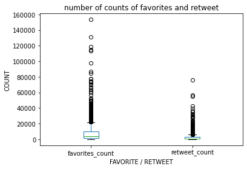

```python
# Distribution of the numbers of tweet of favorites and retweet
df_retweet=df_weratedogs[['favorites_count','retweet_count']]
df_retweet.plot(kind='box', title='number of counts of favorites and retweet').set_ylabel('COUNT');
plt.xlabel('FAVORITE / RETWEET');
```

#### Insight 3

> Those top favorites and retweet may be outliers. I can not go further as to check if those numbers are statistically significant etc.

#### Visualization

> Photo of 2nd best favorites and box plot to show how are the distribution of those counts. Many outliers are there that makes difficult to analyze statistically.

```python
#save to 'twitter_archive_master.csv'
df_weratedogs.to_csv('twitter_archive_master.csv', index=False)
```